# Harvest Control Rule

Chengxue Li

Last update: 2024-12-02

## Hockey-stick Harvest Control Rule

This vignette includes an example of how to use the `whamMSE` (the Woods Hole Assessment Model Management Strategy Evaluation) package to use Hockey-stick harvest control rule in management strategy evaluation.

### 1. Load “WHAM” and “whamMSE”:

```r
library(wham)
library(whamMSE)

main.dir = here::here()
```

### 2. Generate basic information

```r
year_start  <- 1  # starting year in the burn-in period
year_end    <- 20  # end year in the burn-in period
MSE_years   <- 3     # number of years in the feedback loop
# Note: no need to include MSE_years in simulation-estimation

info <- generate_basic_info(n_stocks = 2,
                            n_regions = 2,
                            n_indices = 2,
                            n_fleets = 2,
                            n_seasons = 4,
                            base.years = year_start:year_end,
                            n_feedback_years = MSE_years,
                            life_history = "medium",
                            n_ages = 12,
                            Fbar_ages = 12,
                            recruit_model = 2,
                            F_info = list(F.year1 = 0.2, Fhist = "F-H-L",
                                          Fmax = 2, Fmin = 1, change_time = 0.5, user_F = NULL),
                            catch_info = list(catch_cv = 0.1, catch_Neff = 100),
                            index_info = list(index_cv = 0.1, index_Neff = 100,
                                              fracyr_indices = 0.625, q = 0.2),
                            fracyr_spawn = 0.625)

basic_info = info$basic_info # collect basic information
catch_info = info$catch_info # collect fleet catch information
index_info = info$index_info # collect survey information
F_info = info$F # collect fishing information

# see more details using ?generate_basic_info
```

### 3. Specify movement type and movement rate

```r
basic_info <- generate_NAA_where(basic_info = basic_info, move.type = 2) # "bidirectional" movement

move <- generate_move(basic_info = basic_info, move.type = 2, move.rate = c(0.3,0.1), move.re = "constant")
```

### 4. Configure selecitvity and natural mortality

```r
n_stocks  <- as.integer(basic_info['n_stocks'])
n_regions <- as.integer(basic_info['n_regions'])
n_fleets  <- as.integer(basic_info['n_fleets'])
n_indices <- as.integer(basic_info['n_indices'])
n_ages    <- as.integer(basic_info['n_ages'])

# Selectivity Configuration
fleet_pars <- c(5,1)
index_pars <- c(2,1)
sel <- list(model=rep("logistic",n_fleets+n_indices),
            initial_pars=c(rep(list(fleet_pars),n_fleets),rep(list(index_pars),n_indices)))

# M Configuration
M <- list(model="constant",initial_means=array(0.2, dim = c(n_stocks,n_regions,n_ages)))
```

### 5. Configure numbers-at-age (NAA)

```r
sigma        <- "rec+1"
re_cor       <- "iid"
ini.opt      <- "equilibrium" # option <- c("age-specific-fe", "equilibrium")
Rec_sig      <- 0.5 # (sigma for recruitment)
NAA_sig      <- 0.5 # (sigma for NAA)

sigma_vals = array(NAA_sig, dim = c(n_stocks, n_regions, n_ages)) # n_stocks x n_regions x n_ages
sigma_vals[,,1] = Rec_sig

# Set initial NAA for each stock
log_N1    <- rep(10,n_stocks)
log_N1[1] <- log(exp(10)*2) # N1_stock1 is 2 times higher than N1_stock2
N1_pars   <- generate_ini_N1(log_N1,basic_info,ini.opt)

# Set mean recruitment para. for each stock
mean_rec_par <- list()
for (i in 1:n_stocks) mean_rec_par[[i]] <- exp(log_N1[i])

NAA_re <- list(N1_model=rep(ini.opt,n_stocks),
               sigma=rep(sigma,n_stocks),
               cor=rep(re_cor,n_stocks),
               recruit_model = 2,  # rec random around the mean
               recruit_pars = mean_rec_par,
               sigma_vals = sigma_vals,
               N1_pars = N1_pars,
               NAA_where = basic_info$NAA_where) # NAA_where must be specified in basic_info!
```

### 6. Generate wham input

In this example, instead of using the “multinomial” likelihood for the age composition data, we use a self-weighting likelihood (“logistic-normal-miss0”) in both the OM and EM. Here we use `prepare_wham_input()` function to generate a wham input using the basic information we set above:

```r
input <- prepare_wham_input(basic_info = basic_info,
                            selectivity = sel,
                            M = M,
                            NAA_re = NAA_re,
                            move = move,
                            catch_info = catch_info,
                            index_info = index_info,
                            F = F_info,
                            age_comp = "logistic-normal-miss0")
```

### 7. Generate operating model

```r
random = input$random # check what processes are random effects
input$random = NULL # so inner optimization won't change simulated RE
om <- fit_wham(input, do.fit = F, do.brps = T, MakeADFun.silent = TRUE)
# Note: do.fit must be FALSE (no modeling fitting yet)
```

### 8. Generate dataset

```r
om_with_data <- update_om_fn(om, seed = 123, random = random)
```

### 9. Specify assessment interval and assessment year in the feedback loop

```r
assess.interval <- 3 # Note: assessment interval is 3 years, given the feedback period is 3 years, there will be only 1 assessment
base.years      <- year_start:year_end # Burn-in period
first.year      <- head(base.years,1)
terminal.year   <- tail(base.years,1)
assess.years    <- seq(terminal.year, tail(om$years,1)-assess.interval,by = assess.interval)

mods <- list() # Create a list to save MSE outputs
```

### 10. MSE with “hockey-stick” harvest control rule

For Hockey-stick harvest control rule, users need to set the hcr_type to be 3 (default is 1), set maximum percent of F40% to use for calculating catch in projections (default: max_percent = 75), set minimum percent of F40% to use for calculating catch in projections (default: min_percent = 0.01), set upper bound of overfished level (default = 0.5), and set lower bound of overfished level (default = 0). Please see `advice()` function for more details.

```r
hcr.type <- 3
hcr.opts <- list(max_percent = 75, min_percent = 0.01, BThresh_up = 0.5, BThresh_low = 0)
```

#### EM1: One panmictic model with catch aggregated and with NAA random effects

```r
n_stocks = n_regions = n_fleets = n_indices = 1

sel_em <- list(model=rep("logistic",n_fleets+n_indices),
               initial_pars=c(rep(list(fleet_pars),n_fleets),rep(list(index_pars),n_indices)))

NAA_re_em <- list(N1_model="equilibrium",sigma="rec+1",cor="iid")

M_em <- list(model="constant",initial_means=array(0.2, dim = c(n_stocks,n_regions,n_ages)))

mods[[1]] = loop_through_fn(om = om_with_data,
                            em_info = info,
                            random = random,
                            M_em = M_em,
                            sel_em = sel_em,
                            NAA_re_em = NAA_re_em,
                            move_em = NULL,
                            age_comp_em = "logistic-normal-miss0",
                            em.opt = list(separate.em = TRUE,
                                          separate.em.type = 1,
                                          do.move = FALSE,
                                          est.move = FALSE),
                            assess_years = assess.years,
                            assess_interval = assess.interval,
                            base_years = base.years,
                            year.use = 20,
                            seed = 123,
                            save.sdrep = FALSE)
```

#### EM2: One assessment model (spatially-implicit fleets-as-areas) with NAA random effects

```r
n_stocks = n_regions = 1
n_fleets = n_indices = 2
sel_em <- list(model=rep("logistic",n_fleets+n_indices),
               initial_pars=c(rep(list(fleet_pars),n_fleets),rep(list(index_pars),n_indices)))

NAA_re_em <- list(N1_model="equilibrium",sigma="rec+1",cor="iid")

M_em <- list(model="constant",initial_means=array(0.2, dim = c(n_stocks,n_regions,n_ages)))

mods[[2]] = loop_through_fn(om = om_with_data,
                            em_info = info,
                            random = random,
                            M_em = M_em,
                            sel_em = sel_em,
                            NAA_re_em = NAA_re_em,
                            move_em = NULL,
                            age_comp_em = "logistic-normal-miss0",
                            em.opt = list(separate.em = TRUE,
                                          separate.em.type = 2,
                                          do.move = FALSE,
                                          est.move = FALSE),
                            assess_years = assess.years,
                            assess_interval = assess.interval,
                            base_years = base.years,
                            year.use = 20,
                            seed = 123,
                            save.sdrep = FALSE)
```

#### EM3: Separate single assessment models with NAA random effects

```r
n_stocks = n_regions = n_fleets = n_indices = 1

sel_em <- list(model=rep("logistic",n_fleets+n_indices),
               initial_pars=c(rep(list(fleet_pars),n_fleets),rep(list(index_pars),n_indices)))

NAA_re_em <- list(N1_model="equilibrium",sigma = "rec+1", cor="iid")

M_em <- list(model="constant",initial_means=array(0.2, dim = c(n_stocks,n_regions,n_ages)))

mods[[3]] = loop_through_fn(om = om_with_data,
                            em_info = info,
                            random = random,
                            M_em = M_em,
                            sel_em = sel_em,
                            NAA_re_em = NAA_re_em,
                            move_em = NULL,
                            age_comp_em = "logistic-normal-miss0", # Note: not multinomial!
                            em.opt = list(separate.em = TRUE,
                                          separate.em.type = 3,
                                          do.move = FALSE,
                                          est.move = FALSE),
                            assess_years = assess.years,
                            assess_interval = assess.interval,
                            base_years = base.years,
                            year.use = 20,
                            hcr.type = hcr.type,
                            hcr.opts = hcr.opts,
                            seed = 123,
                            save.sdrep = FALSE)

saveRDS(mods, "Mods.rds")
```

### 11. Compare model performance

The “whamMSE” package has comprehensive output analysis tools, please save the results for Ex6: Performance Analysis Tools. For now we just extract some key quantities (e.g. SSB, catch) for comparison:

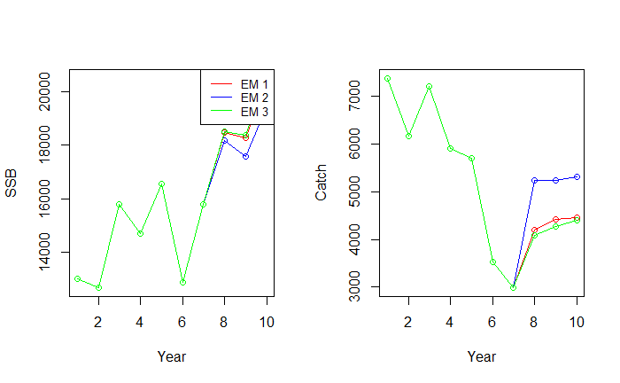

Figure 1

```r
par(mfrow = c(1,2))
SSB_s1_m1 <- mods[[1]]$om$rep$SSB[,1] # Stock 1 SSB in model 1
SSB_s1_m2 <- mods[[2]]$om$rep$SSB[,1] # Stock 1 SSB in model 2
SSB_s1_m3 <- mods[[3]]$om$rep$SSB[,1] # Stock 1 SSB in model 3
plot(SSB_s1_m1[14:23], col = "red", type = "o", ylab = "SSB", xlab = "Year") # Extract SSB from last 10 years
lines(SSB_s1_m2[14:23], col = "blue", type = "o")
lines(SSB_s1_m3[14:23], col = "green", type = "o")

legend("topright", legend=c("EM 1", "EM 2", "EM 3"),
       col=c("red", "blue", "green"), lty=c(1,1), cex=0.8)

Catch_r1_m1 <- mods[[1]]$om$rep$pred_catch[,1] # Stock 1 SSB in model 1
Catch_r1_m2 <- mods[[2]]$om$rep$pred_catch[,1] # Stock 1 SSB in model 2
Catch_r1_m3 <- mods[[3]]$om$rep$pred_catch[,1] # Stock 1 SSB in model 2
plot(Catch_r1_m1[14:23], col = "red", type = "o", ylab = "Catch", xlab = "Year") # Extract catch from last 10 years
lines(Catch_r1_m2[14:23], col = "blue", type = "o")
lines(Catch_r1_m3[14:23], col = "green", type = "o")
```